# Course project

Julien Forthomme

8/1/2020

## Objective

The goal of this project is to create a model capable of predicting how a specific training exercise has been done.

## Data

More information on the dataset is available from this website: http://groupware.les.inf.puc-rio.br/har (see the section on the Weight Lifting Exercise Dataset).

Velloso, E.; Bulling, A.; Gellersen, H.; Ugulino, W.; Fuks, H. Qualitative Activity Recognition of Weight Lifting Exercises. Proceedings of 4th International Conference in Cooperation with SIGCHI (Augmented Human ’13) . Stuttgart, Germany: ACM SIGCHI, 2013.

Loading the training and test datasets. The “na.strings” argument is used to convert missing/error values to “NA”.

```r
original_data <- read.csv("pml-training.csv", na.strings=c("","#DIV/0!", "NA"), header=TRUE)
final_testing <- read.csv("pml-testing.csv", na.strings=c("","#DIV/0!", "NA"), header=TRUE)
```

Loading libraries and setting the seed

```r
library(tidyverse)
library(naniar)
library(caret)
library(rattle)
library(e1071)
library(randomForest)
set.seed(2604)
```

## Exploratory analysis

The original dataset contains 19622 observations of 160 variables. Using the summary function, we can already see that some variables are likely to be of no use as they don’t contain any data, see for example the “kurtosis_yaw_belt” variable.

```r
summary(original_data$kurtosis_yaw_belt)
```

```
##    Mode    NA's
## logical   19622
```

Let’s find the names of all the variables that contain more than 95% of NA in the training set so we can remove those variables from the list of predictors.

```r
removeNAcol <- function(data,pctNA){
        data[,sapply(data, function(x) (mean(is.na(x)))<pctNA)]
}

data <- removeNAcol(original_data, 0.95)
```

We also don’t want the answer to be dependent on the time or the performer

```r
data <- data[,-(1:7)]
```

## Separation in training and testing sets

Let’s separate the dataset in 60/40 (training/testing) based on the “classe” variable.

```r
inTrain <- createDataPartition(y=data$classe, p=0.6, list=FALSE)
training <- data[inTrain,]
testing <- data[-inTrain,]
```

##Preprocessing

### Near zero variables

None of the remaining variables seem to be near zero variables.

```r
nzv <- nearZeroVar(training, saveMetrics= TRUE)
sum(nzv$nzv)
```

```
## [1] 0
```

## Model

The model is supposed to predict the classe (factor variable) using 52 variables. A random forest model is a good pic for that kind of work.

```r
rf <- randomForest(as.factor(classe) ~ ., data=training)
pred_rf <- predict(rf, testing)
confusionMatrix(pred_rf, testing$classe)
```

```
## Confusion Matrix and Statistics
##
##           Reference
## Prediction    A    B    C    D    E
##          A 2230   11    0    0    0
##          B    1 1497    7    0    0
##          C    0   10 1361   15    0
##          D    0    0    0 1271    3
##          E    1    0    0    0 1439
##
## Overall Statistics
##
##                Accuracy : 0.9939
##                  95% CI : (0.9919, 0.9955)
##     No Information Rate : 0.2845
##     P-Value [Acc > NIR] : < 2.2e-16
##
##                   Kappa : 0.9923
##
##  Mcnemar's Test P-Value : NA
##
## Statistics by Class:
##
##                      Class: A Class: B Class: C Class: D Class: E
## Sensitivity            0.9991   0.9862   0.9949   0.9883   0.9979
## Specificity            0.9980   0.9987   0.9961   0.9995   0.9998
## Pos Pred Value         0.9951   0.9947   0.9820   0.9976   0.9993
## Neg Pred Value         0.9996   0.9967   0.9989   0.9977   0.9995
## Prevalence             0.2845   0.1935   0.1744   0.1639   0.1838
## Detection Rate         0.2842   0.1908   0.1735   0.1620   0.1834
## Detection Prevalence   0.2856   0.1918   0.1767   0.1624   0.1835
## Balanced Accuracy      0.9986   0.9925   0.9955   0.9939   0.9989
```

The accuracy of the model used on the testing data set is 0.9939, this model is a keeper!

The varImpPlot function can be used to visualize the variable importance as measured by the random forest.

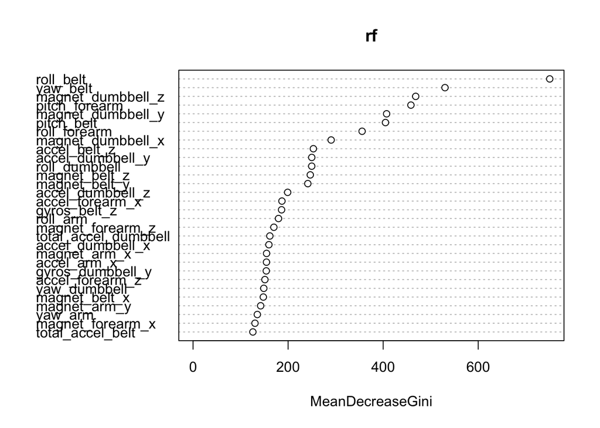

```r
varImpPlot(rf)
```

## Prediction on final testing set

```r
pred_rf <- predict(rf, final_testing)
pred_rf
```

```
##  1  2  3  4  5  6  7  8  9 10 11 12 13 14 15 16 17 18 19 20
##  B  A  B  A  A  E  D  B  A  A  B  C  B  A  E  E  A  B  B  B
## Levels: A B C D E
```

This prediction scores 100% on the Cousera quiz. Yay!